# Section 1: Business Questions to be Answered

#### We are posing as investors, looking to invest in one of the game systems in the market. We have narrowed our options to 2 of the biggest gaming systems on the market today, the PS4 and the XboxOne. We want to look at data to help decide which system is better to invest in right now. Some questions we will look to answer are:

#### Does one system appear in more positive or negative tweets than the other?

#### Based on monetary earnings so far, does one system outweigh the other?

#### Within the gaming community. does one system have a better reputation than the other?

# Section 2: Import Data Sets

```python
# import packages
import json
from collections import Counter
import pandas as pd
import re
import csv
import nltk
from nltk import word_tokenize
from nltk.corpus import stopwords
from nltk.stem.porter import PorterStemmer
from nltk.stem import WordNetLemmatizer
from nltk.sentiment.vader import SentimentIntensityAnalyzer
```

```python
# Load XboxOne tweets
Xboxdata = []
for line in open('data/twitterdataXbox.json'):
    try:
        Xboxdata.append(json.loads(line))
    except:
        pass
print(len(Xboxdata))
```

```
206
```

```python
# Load PS4 tweets
PS4data = []
for line in open('data/twitterdataPS4.json'):
    try:
        PS4data.append(json.loads(line))
    except:
        pass
print(len(PS4data))
```

```
331
```

# Section 3: Text Processing

```python
# Number of Xbox 1 tweets
Xboxtweets = []
for T in Xboxdata:
    if 'text' in T:
        Xboxtweets.append(T)
len(Xboxtweets)
```

```
206
```

```python
# Number of PS4 tweets
PS4tweets = []
for T in PS4data:
    if 'text' in T:
        PS4tweets.append(T)
len(PS4tweets)
```

```
331
```

```python
#extract info from tweets
Xboxids = [T['id_str'] for T in Xboxtweets]
Xboxtimes = [T['created_at'] for T in Xboxtweets]
Xboxtexts = [T['text'] for T in Xboxtweets]
Xboxscreen_names = [T['user']['screen_name'] for T in Xboxtweets]
Xboxfollowers_count = [T['user']['followers_count'] for T in Xboxtweets]
Xboxfriends_count = [T['user']['friends_count'] for T in Xboxtweets]
Xboxnames = [T['user']['name'] for T in Xboxtweets]
Xboxlons = [(T['geo']['coordinates'][1] if T['geo'] else None) for T in Xboxtweets]
Xboxplace_names = [(T['place']['full_name'] if T['place'] else None) for T in Xboxtweets]
Xboxplace_types = [(T['place']['place_type'] if T['place'] else None) for T in Xboxtweets]
Xboxlocation = [status['user']['location'] for status in Xboxtweets if 'user' in status]
```

```python
PS4ids = [T['id_str'] for T in PS4tweets]
PS4times = [T['created_at'] for T in PS4tweets]
PS4texts = [T['text'] for T in PS4tweets]
PS4screen_names = [T['user']['screen_name'] for T in PS4tweets]
PS4followers_count = [T['user']['followers_count'] for T in PS4tweets]
PS4friends_count = [T['user']['friends_count'] for T in PS4tweets]
PS4names = [T['user']['name'] for T in PS4tweets]
PS4lats = [(T['geo']['coordinates'][0] if T['geo'] else None) for T in PS4tweets]
PS4lons = [(T['geo']['coordinates'][1] if T['geo'] else None) for T in PS4tweets]
PS4place_names = [(T['place']['full_name'] if T['place'] else None) for T in PS4tweets]
PS4place_types = [(T['place']['place_type'] if T['place'] else None) for T in PS4tweets]
PS4location = [status['user']['location'] for status in PS4tweets if 'user' in status]
```

```python
#Remove urls
Xboxtexts_no_urls = []

for i in Xboxtexts:
    result = re.sub(r"http\S+", "", i)
    Xboxtexts_no_urls.append(result)

Xboxtexts_no_urls[:3]
```

```
['RT @DeadarticGames: Mortal Kombat 11 - Official Story Trailer\n #MortalKombat11 #MortalKombat #WarnerBros #Ps4Pro #Ps…',
 'RT @DeadarticGames: RAGE 2 – Wasteland Superhero Trailer\n #Rage2 #Rage #Bethesda #Ps4Pro #Ps4 #XboxOneX #XboxOne #PC…',
 'RT @DeadarticGames: Creating Cyberpunk 2077\n #Cyberpunk2077 #CdProjekt #CdProjektRED #Ps4Pro #Ps4 #XboxOneX #XboxOne…']
```

```python
# Remove urls
PS4texts_no_urls = []

for i in PS4texts:
    result = re.sub(r"http\S+", "", i)
    PS4texts_no_urls.append(result)

PS4texts_no_urls[:3]
```

```
['RT @Crunchyroll: NEWS: The Legend of Heroes: Trails of Cold Steel II Game Hits PS4 on June 4\n\n✨ More:  ',
 'RT @VokeRises: Voke Gaming Are A New Team Based In Europe.\nWe Are Currently Looking For The Following.\nContent Creators\n8 PS4 Players\n8 XBO…',
 "If you don't have this game. Get it. It's pretty good."]
```

```python
# Remove Usernames
Xboxtexts_no_urls_usernames = []

for i in Xboxtexts_no_urls:
    result = re.sub(r"(@[A-Za-z0-9]+)","", i)
    Xboxtexts_no_urls_usernames.append(result)

Xboxtexts_no_urls_usernames[:3]
```

```
['RT : Mortal Kombat 11 - Official Story Trailer\n #MortalKombat11 #MortalKombat #WarnerBros #Ps4Pro #Ps…',
 'RT : RAGE 2 – Wasteland Superhero Trailer\n #Rage2 #Rage #Bethesda #Ps4Pro #Ps4 #XboxOneX #XboxOne #PC…',
 'RT : Creating Cyberpunk 2077\n #Cyberpunk2077 #CdProjekt #CdProjektRED #Ps4Pro #Ps4 #XboxOneX #XboxOne…']
```

```python
# Remove Usernames
PS4texts_no_urls_usernames = []

for i in PS4texts_no_urls:
    result = re.sub(r"(@[A-Za-z0-9]+)","", i)
    PS4texts_no_urls_usernames.append(result)

PS4texts_no_urls_usernames[:3]
```

```
['RT : NEWS: The Legend of Heroes: Trails of Cold Steel II Game Hits PS4 on June 4\n\n✨ More:  ',
 'RT : Voke Gaming Are A New Team Based In Europe.\nWe Are Currently Looking For The Following.\nContent Creators\n8 PS4 Players\n8 XBO…',
 "If you don't have this game. Get it. It's pretty good."]
```

```python
#Remove Retweets
Xboxtexts_no_RT = []

for i in Xboxtexts_no_urls_usernames:
    result = re.sub(r"RT : ", "", i)
    Xboxtexts_no_RT.append(result)

Xboxtexts_no_RT[:3]
```

```
['Mortal Kombat 11 - Official Story Trailer\n #MortalKombat11 #MortalKombat #WarnerBros #Ps4Pro #Ps…',
 'RAGE 2 – Wasteland Superhero Trailer\n #Rage2 #Rage #Bethesda #Ps4Pro #Ps4 #XboxOneX #XboxOne #PC…',
 'Creating Cyberpunk 2077\n #Cyberpunk2077 #CdProjekt #CdProjektRED #Ps4Pro #Ps4 #XboxOneX #XboxOne…']
```

```python
#Remove Retweets
PS4texts_no_RT = []

for i in PS4texts_no_urls_usernames:
    result = re.sub(r"RT : ", "", i)
    PS4texts_no_RT.append(result)
PS4texts_no_RT[:3]
```

```
['NEWS: The Legend of Heroes: Trails of Cold Steel II Game Hits PS4 on June 4\n\n✨ More:  ',
 'Voke Gaming Are A New Team Based In Europe.\nWe Are Currently Looking For The Following.\nContent Creators\n8 PS4 Players\n8 XBO…',
 "If you don't have this game. Get it. It's pretty good."]
```

```python
# Remove "\n" from text
Xboxtexts_no_n = []

for i in Xboxtexts_no_RT:
    result = re.sub(r"\n", "", i)
    Xboxtexts_no_n.append(result)

Xboxtexts_no_n[:3]
```

```
['Mortal Kombat 11 - Official Story Trailer #MortalKombat11 #MortalKombat #WarnerBros #Ps4Pro #Ps…',
 'RAGE 2 – Wasteland Superhero Trailer #Rage2 #Rage #Bethesda #Ps4Pro #Ps4 #XboxOneX #XboxOne #PC…',
 'Creating Cyberpunk 2077 #Cyberpunk2077 #CdProjekt #CdProjektRED #Ps4Pro #Ps4 #XboxOneX #XboxOne…']
```

```python
#Remove "\n" from text
PS4texts_no_n = []

for i in PS4texts_no_RT:
    result = re.sub(r"\n", "", i)
    PS4texts_no_n.append(result)

PS4texts_no_n[:3]
```

```
['NEWS: The Legend of Heroes: Trails of Cold Steel II Game Hits PS4 on June 4✨ More:  ',
 'Voke Gaming Are A New Team Based In Europe.We Are Currently Looking For The Following.Content Creators8 PS4 Players8 XBO…',
 "If you don't have this game. Get it. It's pretty good."]
```

```python
#Split Text
Xboxtexts_clean_completely = []

for i in Xboxtexts_no_n:
    result = ' '.join(re.sub(r"(@[A-Za-z0-9]+)|([^0-9A-Za-z \t])|(\w+:\/\/\S+)", "", i).split())
    Xboxtexts_clean_completely.append(result)

Xboxtexts_clean_completely[:3]
```

```
['Mortal Kombat 11 Official Story Trailer MortalKombat11 MortalKombat WarnerBros Ps4Pro Ps',
 'RAGE 2 Wasteland Superhero Trailer Rage2 Rage Bethesda Ps4Pro Ps4 XboxOneX XboxOne PC',
 'Creating Cyberpunk 2077 Cyberpunk2077 CdProjekt CdProjektRED Ps4Pro Ps4 XboxOneX XboxOne']
```

```python
#Split Text
PS4texts_clean_completely = []

for i in PS4texts_no_n:
    result = ' '.join(re.sub(r"(@[A-Za-z0-9]+)|([^0-9A-Za-z \t])|(\w+:\/\/\S+)", "", i).split())
    PS4texts_clean_completely.append(result)

PS4texts_clean_completely[:3]
```

```
['NEWS The Legend of Heroes Trails of Cold Steel II Game Hits PS4 on June 4 More',
 'Voke Gaming Are A New Team Based In EuropeWe Are Currently Looking For The FollowingContent Creators8 PS4 Players8 XBO',
 'If you dont have this game Get it Its pretty good']
```

# Section 4: Sentiment Analysis

## Put data into DataFrame

```python
#Put PS4 data into DataFrame
dfP = pd.DataFrame(PS4texts_clean_completely)
```

```python
#Put XboxOne data into DataFrame
dfX = pd.DataFrame(Xboxtexts_clean_completely)
```

## Vader Sentiment

```python
#Define VaderSentiment
from nltk.sentiment.vader import SentimentIntensityAnalyzer
vs = SentimentIntensityAnalyzer()
```

```python
#Get vader sentiment score for XboxOne Tweets
dfX['score'] = dfX[0].apply(lambda x: vs.polarity_scores(x)['compound'])
dfX.head()
```

|  | 0 | score |
| --- | --- | --- |
| 0 | Mortal Kombat 11 Official Story Trailer Mortal... | 0.0000 |
| 1 | RAGE 2 Wasteland Superhero Trailer Rage2 Rage ... | -0.8374 |
| 2 | Creating Cyberpunk 2077 Cyberpunk2077 CdProjek... | 0.2960 |
| 3 | To celebrate the MLEPlayoffs our amazing spons... | 0.8720 |
| 4 | All NEW Inside Xbox S2 Ep2 InsideXbox XO19 Xbo... | 0.0000 |

```python
#Get vaderSentiment score for PS4 tweets
dfP['score'] = dfP[0].apply(lambda x: vs.polarity_scores(x)['compound'])
dfP.head()
```

|  | 0 | score |
| --- | --- | --- |
| 0 | NEWS The Legend of Heroes Trails of Cold Steel... | 0.5106 |
| 1 | Voke Gaming Are A New Team Based In EuropeWe A... | 0.0000 |
| 2 | If you dont have this game Get it Its pretty good | 0.7269 |
| 3 | RT Follow pour tenter de gagner le jeu DaysGon... | 0.0000 |
| 4 | Pero ese lo tengo para pc y PS4 o si ya tengo ... | -0.2960 |

```python
#Define each type of review
positive_reviewXbox = []
negative_reviewXbox = []
neutral_reviewXbox = []

for i in dfX['score']:
    if i > 0:
        positive_reviewXbox.append(i)
    elif i == 0:
        neutral_reviewXbox.append(i)
    else:
        negative_reviewXbox.append(i)
```

```python
#Find number of pos.,neg., neutral reviews for Xbox tweets
print(len(positive_reviewXbox))
print(len(negative_reviewXbox))
print(len(neutral_reviewXbox))
```

```
90
29
87
```

```python
#Define each type of review
positive_reviewPS4 = []
negative_reviewPS4 = []
neutral_reviewPS4 = []

for i in dfP['score']:
    if i > 0:
        positive_reviewPS4.append(i)
    elif i == 0:
        neutral_reviewPS4.append(i)
    else:
        negative_reviewPS4.append(i)
```

```python
#Find number of pos, neg, neutral reviews for PS4
print(len(positive_reviewPS4))
print(len(negative_reviewPS4))
print(len(neutral_reviewPS4))
```

```
107
45
179
```

# Section 5: Descriptive Analytics

```python
#Tokenize Xbox data
tokens = str(dfX)
tokens = tokens.lower()
tokens = tokens.split()
tokens = re.sub("[^a-zA-Z0-9]", " ", str(tokens))
tokens = word_tokenize(tokens)
tokens = (word for word in tokens if word not in stopwords.words('english'))
```

```python
#Frequency Distribution of Xbox Data
fdist = nltk.FreqDist(tokens)
fdist
```

```
FreqDist({'0': 62, '0000': 25, 'gaiden': 9, 'ninja': 8, 'trailer': 7, 'xbox': 7, '3400': 7, 'fortnite': 6, 'play': 6, 'entire': 6, ...})
```

```python
#Tokenize PS4 data
tokensp = str(dfP)
tokensp = tokensp.lower()
tokensp = tokensp.split()
tokensp = re.sub("[^a-zA-Z0-9]", " ", str(tokensp))
tokensp = word_tokenize(tokensp)
tokensp = (word for word in tokensp if word not in stopwords.words('english'))
```

```python
#Frequency Distribution of PS4 Data
fdistp = nltk.FreqDist(tokensp)
fdistp
```

```
FreqDist({'0': 62, '0000': 32, 'ps4': 17, 'rt': 8, '1': 4, 'get': 4, 'game': 3, 'player': 3, '2023': 3, 'na': 3, ...})
```

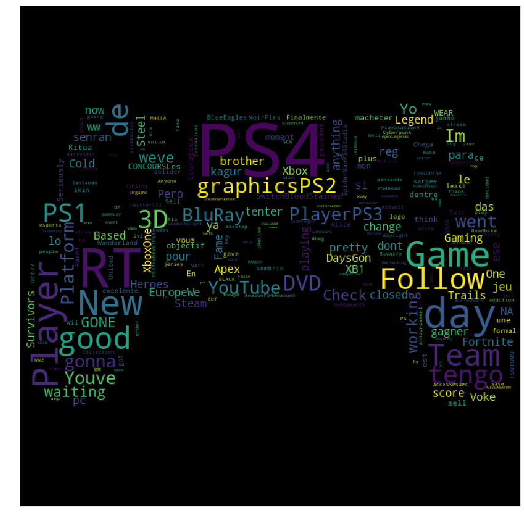

[figure not shown]

```python
#Word Cloud PS4 tweets
from os import path
from PIL import Image
import numpy as np
import matplotlib.pyplot as plt
from wordcloud import WordCloud, STOPWORDS
from nltk.corpus import stopwords

# Read the whole text.
text = str(dfP)

stopwords = set(STOPWORDS)
auto_mask = np.array(Image.open("data/Ps4.jpg"))

wc = WordCloud(background_color="black", max_words=2000, mask=auto_mask,
               stopwords=stopwords)
# generate word cloud
wc.generate(text)

# show
plt.figure(figsize=(15,15))
plt.imshow(wc)
plt.axis("off")

plt.figure()
plt.imshow(auto_mask, cmap=plt.cm.gray)
plt.axis("off")
plt.savefig("data/Auto.png")
plt.savefig("data/Auto.pdf")
```

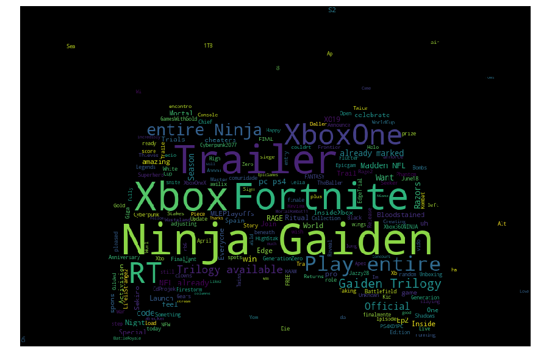

[figure not shown]

```python
#Word Cloud Xbox tweets
text = str(dfX)

stopwords = set(STOPWORDS)
auto_mask = np.array(Image.open("data/Xbox1.jpg"))

wc = WordCloud(background_color="black", max_words=2000, mask=auto_mask,
               stopwords=stopwords)
# generate word cloud
wc.generate(text)

# show
plt.figure(figsize=(15,15))
plt.imshow(wc)
plt.axis("off")

plt.figure()
plt.imshow(auto_mask, cmap=plt.cm.gray)
plt.axis("off")
plt.savefig("data/Auto.png")
plt.savefig("data/Auto.pdf")
```